# Part I - (Ford GoBike System Data)

## Introduction

This data set includes information about individual rides made in a bike-sharing system covering the greater San Francisco Bay area.

I will be understanding the data structure and brainstorming some more questions, conducting preliminary data wrangling, such as changing data types of specific columns, and make sure you don't have too many missing values I will be using the Question-Visualization-Observations" framework. which involves asking a question from the data, creating a visualization to find answers, and then recording observations.And finally systematically exploring the data starting with Univariate, and moving on to Bivariate and Multivariate explorations. I also documented the flow of exploration in the markdown cells and recorded my conclusions on my main findings and reflected on the steps taken during the data exploration.

## Preliminary Wrangling

```python
# import all packages and set plots to be embedded inline
import numpy as np
import pandas as pd
import matplotlib.pyplot as plt
import seaborn as sb
from scipy import stats

%matplotlib inline
```

> Load in your dataset and describe its properties through the questions below. Try and motivate your exploration goals through this section.

```python
fordbikes=pd.read_csv('201902-fordgobike-tripdata.csv')
fordbikes.head()
```

|  | duration_sec | start_time | end_time | start_station_id | start_station_name | start_station_latitude | start_station_longitude | end_station_id | end_station_name | end_station_latitude | end_station_longitude | bike_id | user_type | member_birth_year | member_gender | bike_share_for_all_trip |
| --- | --- | --- | --- | --- | --- | --- | --- | --- | --- | --- | --- | --- | --- | --- | --- | --- |
| 0 | 52185 | 2019-02-28 17:32:10.1450 | 2019-03-01 08:01:55.9750 | 21.0 | Montgomery St BART Station (Market St at 2nd St) | 37.789625 | -122.400811 | 13.0 | Commercial St at Montgomery St | 37.794231 | -122.402923 | 4902 | Customer | 1984.0 | Male | No |
| 1 | 42521 | 2019-02-28 18:53:21.7890 | 2019-03-01 06:42:03.0560 | 23.0 | The Embarcadero at Steuart St | 37.791464 | -122.391034 | 81.0 | Berry St at 4th St | 37.775880 | -122.393170 | 2535 | Customer | NaN | NaN | No |
| 2 | 61854 | 2019-02-28 12:13:13.2180 | 2019-03-01 05:24:08.1460 | 86.0 | Market St at Dolores St | 37.769305 | -122.426826 | 3.0 | Powell St BART Station (Market St at 4th St) | 37.786375 | -122.404904 | 5905 | Customer | 1972.0 | Male | No |
| 3 | 36490 | 2019-02-28 17:54:26.0100 | 2019-03-01 04:02:36.8420 | 375.0 | Grove St at Masonic Ave | 37.774836 | -122.446546 | 70.0 | Central Ave at Fell St | 37.773311 | -122.444293 | 6638 | Subscriber | 1989.0 | Other | No |
| 4 | 1585 | 2019-02-28 23:54:18.5490 | 2019-03-01 00:20:44.0740 | 7.0 | Frank H Ogawa Plaza | 37.804562 | -122.271738 | 222.0 | 10th Ave at E 15th St | 37.792714 | -122.248780 | 4898 | Subscriber | 1974.0 | Male | Yes |

```python
fordbikes.describe()
```

|  | duration_sec | start_station_id | start_station_latitude | start_station_longitude | end_station_id | end_station_latitude | end_station_longitude | bike_id | member_birth_year |
| --- | --- | --- | --- | --- | --- | --- | --- | --- | --- |
| count | 183412.000000 | 183215.000000 | 183412.000000 | 183412.000000 | 183215.000000 | 183412.000000 | 183412.000000 | 183412.000000 | 175147.000000 |
| mean | 726.078435 | 138.590427 | 37.771223 | -122.352664 | 136.249123 | 37.771427 | -122.352250 | 4472.906375 | 1984.806437 |
| std | 1794.389780 | 111.778864 | 0.099581 | 0.117097 | 111.515131 | 0.099490 | 0.116673 | 1664.383394 | 10.116689 |
| min | 61.000000 | 3.000000 | 37.317298 | -122.453704 | 3.000000 | 37.317298 | -122.453704 | 11.000000 | 1878.000000 |
| 25% | 325.000000 | 47.000000 | 37.770083 | -122.412408 | 44.000000 | 37.770407 | -122.411726 | 3777.000000 | 1980.000000 |
| 50% | 514.000000 | 104.000000 | 37.780760 | -122.398285 | 100.000000 | 37.781010 | -122.398279 | 4958.000000 | 1987.000000 |
| 75% | 796.000000 | 239.000000 | 37.797280 | -122.286533 | 235.000000 | 37.797320 | -122.288045 | 5502.000000 | 1992.000000 |
| max | 85444.000000 | 398.000000 | 37.880222 | -121.874119 | 398.000000 | 37.880222 | -121.874119 | 6645.000000 | 2001.000000 |

```python
# high-level overview of data shape and composition
print(fordbikes.shape)
print(fordbikes.dtypes)
print(fordbikes.head(10))
```

```
(183412, 16)
duration_sec                 int64
start_time                  object
end_time                    object
start_station_id           float64
start_station_name          object
start_station_latitude     float64
start_station_longitude    float64
end_station_id             float64
end_station_name            object
end_station_latitude       float64
end_station_longitude      float64
bike_id                      int64
user_type                   object
member_birth_year          float64
member_gender               object
bike_share_for_all_trip     object
dtype: object
   duration_sec                start_time                  end_time  \
0         52185  2019-02-28 17:32:10.1450  2019-03-01 08:01:55.9750
1         42521  2019-02-28 18:53:21.7890  2019-03-01 06:42:03.0560
2         61854  2019-02-28 12:13:13.2180  2019-03-01 05:24:08.1460
3         36490  2019-02-28 17:54:26.0100  2019-03-01 04:02:36.8420
4          1585  2019-02-28 23:54:18.5490  2019-03-01 00:20:44.0740
5          1793  2019-02-28 23:49:58.6320  2019-03-01 00:19:51.7600
6          1147  2019-02-28 23:55:35.1040  2019-03-01 00:14:42.5880
7          1615  2019-02-28 23:41:06.7660  2019-03-01 00:08:02.7560
8          1570  2019-02-28 23:41:48.7900  2019-03-01 00:07:59.7150
9          1049  2019-02-28 23:49:47.6990  2019-03-01 00:07:17.0250

   start_station_id                                start_station_name  \
0              21.0  Montgomery St BART Station (Market St at 2nd St)
1              23.0                     The Embarcadero at Steuart St
2              86.0                           Market St at Dolores St
3             375.0                           Grove St at Masonic Ave
4               7.0                               Frank H Ogawa Plaza
5              93.0                      4th St at Mission Bay Blvd S
6             300.0                              Palm St at Willow St
7              10.0                        Washington St at Kearny St
8              10.0                        Washington St at Kearny St
```

[output cut: 34 more lines]

```
7            -122.421025     6329  Subscriber             1989.0
8            -122.421025     6548  Subscriber             1988.0
9            -122.421339     6488  Subscriber             1992.0

  member_gender bike_share_for_all_trip
0          Male                      No
1           NaN                      No
2          Male                      No
3         Other                      No
4          Male                     Yes
5          Male                      No
6        Female                      No
7          Male                      No
8         Other                      No
9          Male                      No
```

```python
fordbikes.describe()
```

|  | duration_sec | start_station_id | start_station_latitude | start_station_longitude | end_station_id | end_station_latitude | end_station_longitude | bike_id | member_birth_year |
| --- | --- | --- | --- | --- | --- | --- | --- | --- | --- |
| count | 183412.000000 | 183215.000000 | 183412.000000 | 183412.000000 | 183215.000000 | 183412.000000 | 183412.000000 | 183412.000000 | 175147.000000 |
| mean | 726.078435 | 138.590427 | 37.771223 | -122.352664 | 136.249123 | 37.771427 | -122.352250 | 4472.906375 | 1984.806437 |
| std | 1794.389780 | 111.778864 | 0.099581 | 0.117097 | 111.515131 | 0.099490 | 0.116673 | 1664.383394 | 10.116689 |
| min | 61.000000 | 3.000000 | 37.317298 | -122.453704 | 3.000000 | 37.317298 | -122.453704 | 11.000000 | 1878.000000 |
| 25% | 325.000000 | 47.000000 | 37.770083 | -122.412408 | 44.000000 | 37.770407 | -122.411726 | 3777.000000 | 1980.000000 |
| 50% | 514.000000 | 104.000000 | 37.780760 | -122.398285 | 100.000000 | 37.781010 | -122.398279 | 4958.000000 | 1987.000000 |
| 75% | 796.000000 | 239.000000 | 37.797280 | -122.286533 | 235.000000 | 37.797320 | -122.288045 | 5502.000000 | 1992.000000 |
| max | 85444.000000 | 398.000000 | 37.880222 | -121.874119 | 398.000000 | 37.880222 | -121.874119 | 6645.000000 | 2001.000000 |

```python
fordbikes.info()
```

```
<class 'pandas.core.frame.DataFrame'>
RangeIndex: 183412 entries, 0 to 183411
Data columns (total 16 columns):
duration_sec               183412 non-null int64
start_time                 183412 non-null object
end_time                   183412 non-null object
start_station_id           183215 non-null float64
start_station_name         183215 non-null object
start_station_latitude     183412 non-null float64
start_station_longitude    183412 non-null float64
end_station_id             183215 non-null float64
end_station_name           183215 non-null object
end_station_latitude       183412 non-null float64
end_station_longitude      183412 non-null float64
bike_id                    183412 non-null int64
user_type                  183412 non-null object
member_birth_year          175147 non-null float64
member_gender              175147 non-null object
bike_share_for_all_trip    183412 non-null object
dtypes: float64(7), int64(2), object(7)
memory usage: 22.4+ MB
```

```python
fordbikes.duplicated().sum()
```

```
0
```

```python
fordbikes.isnull().sum()
```

```
duration_sec                  0
start_time                    0
end_time                      0
start_station_id            197
start_station_name          197
start_station_latitude        0
start_station_longitude       0
end_station_id              197
end_station_name            197
end_station_latitude          0
end_station_longitude         0
bike_id                       0
user_type                     0
member_birth_year          8265
member_gender              8265
bike_share_for_all_trip       0
dtype: int64
```

```python
fordbikes.member_birth_year.value_counts()
```

```
1988.0    10236
1993.0     9325
1989.0     8972
1990.0     8658
1991.0     8498
1992.0     8250
1987.0     8018
1986.0     7973
1994.0     7660
1995.0     7423
1985.0     7028
1984.0     6562
1983.0     5954
1980.0     5024
1982.0     4990
1996.0     4640
1981.0     4345
1979.0     3756
1997.0     3481
1998.0     3208
1978.0     2830
1977.0     2725
1974.0     2633
1999.0     2528
1975.0     2503
1976.0     2442
1973.0     2080
1968.0     1928
1971.0     1924
1972.0     1909
          ...
1954.0      301
1952.0      189
1951.0      180
1950.0      178
1953.0      158
1947.0      135
1955.0      134
1945.0      105
1949.0       99
1931.0       89
1900.0       53
1948.0       51
2001.0       34
1943.0       30
1942.0       21
1933.0       20
1946.0       19
1902.0       11
1939.0       11
1941.0        9
1901.0        6
1938.0        3
1920.0        3
1934.0        2
1944.0        2
1930.0        1
1910.0        1
1927.0        1
1928.0        1
1878.0        1
Name: member_birth_year, Length: 75, dtype: int64
```

```python
fordbikes.member_gender.value_counts()
```

```
Male      130651
Female     40844
Other       3652
Name: member_gender, dtype: int64
```

```python
# descriptive statistics for numeric variables
print(fordbikes.describe())
```

```
        duration_sec  start_station_id  start_station_latitude  \
count  183412.000000     183215.000000           183412.000000
mean      726.078435        138.590427               37.771223
std      1794.389780        111.778864                0.099581
min        61.000000          3.000000               37.317298
25%       325.000000         47.000000               37.770083
50%       514.000000        104.000000               37.780760
75%       796.000000        239.000000               37.797280
max     85444.000000        398.000000               37.880222

       start_station_longitude  end_station_id  end_station_latitude  \
count            183412.000000   183215.000000         183412.000000
mean               -122.352664      136.249123             37.771427
std                   0.117097      111.515131              0.099490
min                -122.453704        3.000000             37.317298
25%                -122.412408       44.000000             37.770407
50%                -122.398285      100.000000             37.781010
75%                -122.286533      235.000000             37.797320
max                -121.874119      398.000000             37.880222

       end_station_longitude        bike_id  member_birth_year
count          183412.000000  183412.000000      175147.000000
mean             -122.352250    4472.906375        1984.806437
std                 0.116673    1664.383394          10.116689
min              -122.453704      11.000000        1878.000000
25%              -122.411726    3777.000000        1980.000000
50%              -122.398279    4958.000000        1987.000000
75%              -122.288045    5502.000000        1992.000000
max              -121.874119    6645.000000        2001.000000
```

### What is the structure of your dataset?

There are 183,412 fordbike rides in the dataset with 16 features (duration_sec,start_time,end_time,start_station_id, start_station_latitude,start_station_longitude,end_station_id,end_station_latitude,end_station_longitude,bike_id, member_birth_yea,member_gender and bike_share_for_all_trip). Most variables are numeric in nature, but the variables,duration_sec, start_time,end_time, and member birthyear are ordered factor variables, having year starting from 1878 to 2001 and start_time and end_time these would need to be changed to datetime and int respectively, to give us the days of the week the rides took place,which could be from monday to sunday.The dataset also has alot of null values in member_birth_year,member_gender,end_station_id,end_station_name,start_station_name and start_station_id, these would be removed to give us a more descriptive data

### What is/are the main feature(s) of interest in your dataset?

The main feature of interest in my dataset is the duration_sec,start_time,end_time and the member_birth_year.I am most interested in figuring out what category of member_birth_year enjoyed the most bike rides in the fordbikes dataset and what day of the week had the most bike rides.

### What features in the dataset do you think will help support your investigation into your feature(s) of interest?

I expect that duration_sec,start_time and end_time will have the strongest effect on each biker's rides, duration_sec: the larger the duration, the higher the end_time, end_station_latitude and end_station_longitude . I also think that the other features such as the start_station_name,start_station_latitude, start_station_longitude, user_type,member_birth_year,member_gender,bike_share_for_all_trip, will have effects on the rides, though to a much smaller degree than the main effect of duration_sec.

### Cleaning the Dataset alittle

### Make a copy of the fordbikes dataset

```python
fordbikeRiders = fordbikes.copy()
```

```python
fordbikeRiders.head(2)
```

|  | duration_sec | start_time | end_time | start_station_id | start_station_name | start_station_latitude | start_station_longitude | end_station_id | end_station_name | end_station_latitude | end_station_longitude | bike_id | user_type | member_birth_year | member_gender | bike_share_for_all_trip |
| --- | --- | --- | --- | --- | --- | --- | --- | --- | --- | --- | --- | --- | --- | --- | --- | --- |
| 0 | 52185 | 2019-02-28 17:32:10.1450 | 2019-03-01 08:01:55.9750 | 21.0 | Montgomery St BART Station (Market St at 2nd St) | 37.789625 | -122.400811 | 13.0 | Commercial St at Montgomery St | 37.794231 | -122.402923 | 4902 | Customer | 1984.0 | Male | No |
| 1 | 42521 | 2019-02-28 18:53:21.7890 | 2019-03-01 06:42:03.0560 | 23.0 | The Embarcadero at Steuart St | 37.791464 | -122.391034 | 81.0 | Berry St at 4th St | 37.775880 | -122.393170 | 2535 | Customer | NaN | NaN | No |

### Change the columns with wrong data types,start_time,end_time as datetime

```python
fordbikeRiders["start_time"]=fordbikeRiders["start_time"].astype("datetime64[ns]")
```

```python
fordbikeRiders["end_time"]=fordbikeRiders["end_time"].astype("datetime64[ns]")
```

### Next we check if the change has taken effect

```python
fordbikeRiders.info()
```

```
<class 'pandas.core.frame.DataFrame'>
RangeIndex: 183412 entries, 0 to 183411
Data columns (total 16 columns):
duration_sec               183412 non-null int64
start_time                 183412 non-null datetime64[ns]
end_time                   183412 non-null datetime64[ns]
start_station_id           183215 non-null float64
start_station_name         183215 non-null object
start_station_latitude     183412 non-null float64
start_station_longitude    183412 non-null float64
end_station_id             183215 non-null float64
end_station_name           183215 non-null object
end_station_latitude       183412 non-null float64
end_station_longitude      183412 non-null float64
bike_id                    183412 non-null int64
user_type                  183412 non-null object
member_birth_year          175147 non-null float64
member_gender              175147 non-null object
bike_share_for_all_trip    183412 non-null object
dtypes: datetime64[ns](2), float64(7), int64(2), object(5)
memory usage: 22.4+ MB
```

### Next we drop rows with missing data

```python
fordbikeRiders=fordbikeRiders.dropna()
```

### Check if the drop has taken effect

```python
fordbikeRiders.isnull().sum()
```

```
duration_sec               0
start_time                 0
end_time                   0
start_station_id           0
start_station_name         0
start_station_latitude     0
start_station_longitude    0
end_station_id             0
end_station_name           0
end_station_latitude       0
end_station_longitude      0
bike_id                    0
user_type                  0
member_birth_year          0
member_gender              0
bike_share_for_all_trip    0
dtype: int64
```

### Next we also change member_birth_year,start_station_id and end_station_id to interger to make it easier for us to manipulate the data

```python
fordbikeRiders['start_station_id'] = fordbikeRiders['start_station_id'].astype(int)
```

```python
fordbikeRiders["member_birth_year"]=fordbikeRiders["member_birth_year"].astype("int")
```

```python
fordbikeRiders["end_station_id"]=fordbikeRiders["end_station_id"].astype("int")
```

### Check if the data type changes have been effected

```python
fordbikeRiders.info()
```

```
<class 'pandas.core.frame.DataFrame'>
Int64Index: 174952 entries, 0 to 183411
Data columns (total 16 columns):
duration_sec               174952 non-null int64
start_time                 174952 non-null datetime64[ns]
end_time                   174952 non-null datetime64[ns]
start_station_id           174952 non-null int64
start_station_name         174952 non-null object
start_station_latitude     174952 non-null float64
start_station_longitude    174952 non-null float64
end_station_id             174952 non-null int64
end_station_name           174952 non-null object
end_station_latitude       174952 non-null float64
end_station_longitude      174952 non-null float64
bike_id                    174952 non-null int64
user_type                  174952 non-null object
member_birth_year          174952 non-null int64
member_gender              174952 non-null object
bike_share_for_all_trip    174952 non-null object
dtypes: datetime64[ns](2), float64(4), int64(5), object(5)
memory usage: 22.7+ MB
```

### Separating day and hour from start_time and end_time using lambda function

#### by extracting the day and hour from the time and allow it have its own column

```python
fordbikeRiders["start_day"] = fordbikeRiders.start_time.apply(lambda x: x.strftime("%a"))
fordbikeRiders["start_hour"] =fordbikeRiders.start_time.apply(lambda x: int(x.strftime("%H")))

fordbikeRiders["end_day"] = fordbikeRiders.end_time.apply(lambda x: x.strftime("%a"))
fordbikeRiders["end_hour"] = fordbikeRiders.end_time.apply(lambda x: int(x.strftime("%H")))
```

### Check to see if the day and time has been extracted and having column with names start_day,start_hour,end_day,end_hour

```python
fordbikeRiders.head(2)
```

|  | duration_sec | start_time | end_time | start_station_id | start_station_name | start_station_latitude | start_station_longitude | end_station_id | end_station_name | end_station_latitude | end_station_longitude | bike_id | user_type | member_birth_year | member_gender | bike_share_for_all_trip | start_day | start_hour | end_day | end_hour |
| --- | --- | --- | --- | --- | --- | --- | --- | --- | --- | --- | --- | --- | --- | --- | --- | --- | --- | --- | --- | --- |
| 0 | 52185 | 2019-02-28 17:32:10.145 | 2019-03-01 08:01:55.975 | 21 | Montgomery St BART Station (Market St at 2nd St) | 37.789625 | -122.400811 | 13 | Commercial St at Montgomery St | 37.794231 | -122.402923 | 4902 | Customer | 1984 | Male | No | Thu | 17 | Fri | 8 |
| 2 | 61854 | 2019-02-28 12:13:13.218 | 2019-03-01 05:24:08.146 | 86 | Market St at Dolores St | 37.769305 | -122.426826 | 3 | Powell St BART Station (Market St at 4th St) | 37.786375 | -122.404904 | 5905 | Customer | 1972 | Male | No | Thu | 12 | Fri | 5 |

### Change start_day, end_day to ordinal variables¶

```python
ordinal_var_dict = {'start_day': ['Mon', "Tue", "Wed", "Thu", "Fri", "Sat", "Sun"],
                    'end_day': ['Mon', "Tue", "Wed", "Thu", "Fri", "Sat", "Sun"]}

for var in ordinal_var_dict:
    ordered_var = pd.api.types.CategoricalDtype(ordered = True, categories = ordinal_var_dict[var])
    fordbikeRiders[var] = fordbikeRiders[var].astype(ordered_var)
```

### Remove unneccessary columns in our dataset columns such as start_station_latitude,start_station_longitude,end_station_latitude and end_station_longitude

```python
# drop the location points
fordbikeRiders.drop(["start_station_latitude", "start_station_longitude", "end_station_latitude", "end_station_longitude"], axis = 1, inplace = True)
```

### Check if unneccessary columns have been removed

```python
fordbikeRiders.info()
```

```
<class 'pandas.core.frame.DataFrame'>
Int64Index: 174952 entries, 0 to 183411
Data columns (total 16 columns):
duration_sec               174952 non-null int64
start_time                 174952 non-null datetime64[ns]
end_time                   174952 non-null datetime64[ns]
start_station_id           174952 non-null int64
start_station_name         174952 non-null object
end_station_id             174952 non-null int64
end_station_name           174952 non-null object
bike_id                    174952 non-null int64
user_type                  174952 non-null object
member_birth_year          174952 non-null int64
member_gender              174952 non-null object
bike_share_for_all_trip    174952 non-null object
start_day                  174952 non-null category
start_hour                 174952 non-null int64
end_day                    174952 non-null category
end_hour                   174952 non-null int64
dtypes: category(2), datetime64[ns](2), int64(7), object(5)
memory usage: 20.4+ MB
```

```python
start_stations = fordbikeRiders.groupby(["start_station_id"]).sum(numeric_only = True).reset_index()

start_stations["count"] = fordbikeRiders.groupby(["start_station_id"]).count()["duration_sec"].reset_index()["duration_sec"]
start_stations["avg_dur"] = start_stations["duration_sec"]/start_stations["count"]

start_stations.sort_values(by=["avg_dur"], ascending=False)
```

|  | start_station_id | duration_sec | end_station_id | bike_id | member_birth_year | start_hour | end_hour | count | avg_dur |
| --- | --- | --- | --- | --- | --- | --- | --- | --- | --- |
| 38 | 46 | 140342 | 12107 | 231496 | 104910 | 766 | 793 | 53 | 2647.962264 |
| 267 | 300 | 7402 | 382 | 11610 | 5970 | 53 | 32 | 3 | 2467.333333 |
| 201 | 229 | 42768 | 5371 | 76341 | 45576 | 289 | 304 | 23 | 1859.478261 |
| 320 | 378 | 50114 | 8611 | 94774 | 55404 | 406 | 417 | 28 | 1789.785714 |
| 319 | 377 | 1331415 | 115154 | 3772875 | 1548384 | 10005 | 10314 | 780 | 1706.942308 |
| 284 | 318 | 61003 | 11163 | 123740 | 73476 | 606 | 620 | 37 | 1648.729730 |
| 304 | 358 | 78576 | 7413 | 237355 | 95244 | 355 | 374 | 48 | 1637.000000 |
| 25 | 29 | 606603 | 41211 | 1897278 | 737315 | 4885 | 4997 | 372 | 1630.653226 |
| 321 | 380 | 388379 | 40172 | 1247950 | 476937 | 3039 | 3116 | 240 | 1618.245833 |
| 200 | 228 | 55175 | 8067 | 109125 | 69095 | 323 | 336 | 35 | 1576.428571 |
| 318 | 375 | 498653 | 36656 | 1560512 | 636334 | 3517 | 3581 | 321 | 1553.436137 |
| 308 | 362 | 50606 | 7548 | 172524 | 71407 | 429 | 448 | 36 | 1405.722222 |
| 315 | 371 | 1230619 | 102903 | 4358985 | 1759230 | 11437 | 11737 | 886 | 1388.960497 |
| 231 | 259 | 318462 | 56799 | 1063704 | 460343 | 3219 | 3313 | 232 | 1372.681034 |
| 306 | 360 | 74924 | 7995 | 277824 | 108968 | 689 | 707 | 55 | 1362.254545 |
| 190 | 218 | 209429 | 26500 | 659366 | 305598 | 1879 | 1875 | 154 | 1359.928571 |
| 132 | 154 | 262576 | 42073 | 933994 | 384927 | 2581 | 2606 | 194 | 1353.484536 |
| 133 | 155 | 204903 | 32616 | 721688 | 303612 | 2251 | 2307 | 153 | 1339.235294 |
| 326 | 388 | 22432 | 5330 | 78762 | 33789 | 222 | 227 | 17 | 1319.529412 |
| 265 | 298 | 38188 | 9177 | 112487 | 59462 | 455 | 440 | 30 | 1272.933333 |
| 305 | 359 | 30116 | 3686 | 116061 | 49714 | 320 | 328 | 25 | 1204.640000 |
| 59 | 72 | 765677 | 60377 | 2968992 | 1261403 | 7405 | 7532 | 636 | 1203.894654 |
| 307 | 361 | 61967 | 5477 | 269145 | 105102 | 574 | 590 | 53 | 1169.188679 |
| 58 | 71 | 693282 | 59660 | 2597861 | 1185230 | 6825 | 6937 | 597 | 1161.276382 |
| 148 | 172 | 105166 | 19112 | 340244 | 180120 | 1352 | 1358 | 91 | 1155.670330 |
| 268 | 301 | 10248 | 2666 | 35791 | 17889 | 106 | 109 | 9 | 1138.666667 |
| 7 | 10 | 824833 | 65329 | 3669828 | 1453132 | 10473 | 10461 | 732 | 1126.821038 |
| 206 | 234 | 10084 | 1981 | 35514 | 17913 | 158 | 160 | 9 | 1120.444444 |
| 327 | 389 | 14523 | 4122 | 62440 | 25725 | 185 | 190 | 13 | 1117.153846 |
| 33 | 39 | 327832 | 37156 | 1400255 | 595621 | 3159 | 3174 | 300 | 1092.773333 |
| ... | ... | ... | ... | ... | ... | ... | ... | ... | ... |
| 179 | 206 | 32854 | 13186 | 261731 | 132759 | 777 | 783 | 67 | 490.358209 |
| 141 | 164 | 42846 | 15412 | 382901 | 174697 | 919 | 935 | 88 | 486.886364 |
| 184 | 212 | 120926 | 46366 | 1008157 | 493521 | 2837 | 2870 | 249 | 485.646586 |
| 177 | 204 | 60302 | 23792 | 453075 | 251324 | 1522 | 1542 | 127 | 474.818898 |
| 276 | 310 | 413527 | 263161 | 3416762 | 1739061 | 13895 | 13975 | 873 | 473.684994 |
| 264 | 297 | 23189 | 14799 | 183534 | 97142 | 552 | 558 | 49 | 473.244898 |
| 212 | 240 | 337393 | 177744 | 2916775 | 1424491 | 10244 | 10214 | 715 | 471.878322 |
| 237 | 268 | 116683 | 61306 | 971837 | 500343 | 3037 | 3066 | 252 | 463.027778 |
| 223 | 251 | 135322 | 73666 | 1204590 | 581605 | 3698 | 3738 | 293 | 461.849829 |
| 238 | 269 | 213869 | 114015 | 1953671 | 936562 | 6239 | 6311 | 470 | 455.040426 |
| 30 | 35 | 45746 | 28378 | 365576 | 200772 | 1449 | 1459 | 101 | 452.930693 |
| 294 | 341 | 128648 | 85575 | 1119077 | 567435 | 4233 | 4246 | 285 | 451.396491 |
| 275 | 309 | 69480 | 47437 | 588414 | 306080 | 2383 | 2393 | 154 | 451.168831 |
| 164 | 190 | 77774 | 33635 | 590050 | 343219 | 2793 | 2809 | 173 | 449.560694 |
| 280 | 314 | 45452 | 29798 | 346940 | 202361 | 1579 | 1594 | 102 | 445.607843 |
| 303 | 357 | 144298 | 99455 | 1250702 | 647426 | 3988 | 4007 | 325 | 443.993846 |
| 316 | 372 | 95423 | 37484 | 935195 | 428420 | 2650 | 2688 | 216 | 441.773148 |
| 283 | 317 | 159970 | 114524 | 1495306 | 737387 | 4905 | 4936 | 370 | 432.351351 |
| 202 | 230 | 135289 | 52752 | 1223606 | 620683 | 3576 | 3597 | 313 | 432.233227 |
| 288 | 327 | 96498 | 67978 | 867867 | 451960 | 3391 | 3412 | 227 | 425.101322 |
| 243 | 275 | 31500 | 23462 | 274873 | 148581 | 908 | 916 | 75 | 420.000000 |
| 225 | 253 | 326950 | 185421 | 2901633 | 1557773 | 10452 | 10538 | 781 | 418.629962 |
| 205 | 233 | 72798 | 31347 | 730141 | 349071 | 1806 | 1826 | 176 | 413.625000 |
| 152 | 176 | 393703 | 186594 | 3959116 | 1893775 | 15169 | 15285 | 955 | 412.254450 |
| 236 | 267 | 198623 | 117329 | 2068228 | 968994 | 6127 | 6193 | 487 | 407.850103 |
| 244 | 276 | 114326 | 74916 | 959874 | 563991 | 4023 | 4030 | 283 | 403.978799 |
| 279 | 313 | 32699 | 25865 | 245721 | 168828 | 1451 | 1457 | 85 | 384.694118 |
| 203 | 231 | 34577 | 14302 | 329446 | 178855 | 859 | 867 | 90 | 384.188889 |
| 255 | 287 | 11445 | 9954 | 112408 | 63651 | 547 | 557 | 32 | 357.656250 |
| 198 | 226 | 6633 | 4390 | 64041 | 37743 | 255 | 256 | 19 | 349.105263 |

329 rows × 9 columns

```python
# descriptive statistics for numeric variables
print(fordbikeRiders.describe())
```

```
        duration_sec  start_station_id  end_station_id        bike_id  \
count  174952.000000     174952.000000   174952.000000  174952.000000
mean      704.002744        139.002126      136.604486    4482.587555
std      1642.204905        111.648819      111.335635    1659.195937
min        61.000000          3.000000        3.000000      11.000000
25%       323.000000         47.000000       44.000000    3799.000000
50%       510.000000        104.000000      101.000000    4960.000000
75%       789.000000        239.000000      238.000000    5505.000000
max     84548.000000        398.000000      398.000000    6645.000000

       member_birth_year     start_hour       end_hour
count      174952.000000  174952.000000  174952.000000
mean         1984.803135      13.456165      13.609533
std            10.118731       4.734282       4.748029
min          1878.000000       0.000000       0.000000
25%          1980.000000       9.000000       9.000000
50%          1987.000000      14.000000      14.000000
75%          1992.000000      17.000000      18.000000
max          2001.000000      23.000000      23.000000
```

```python
#looking into the outliers,lets see a sample of some of them
fordbikeRiders[fordbikeRiders.duration_sec < 10000].sample(10)
```

|  | duration_sec | start_time | end_time | start_station_id | start_station_name | end_station_id | end_station_name | bike_id | user_type | member_birth_year | member_gender | bike_share_for_all_trip | start_day | start_hour | end_day | end_hour |
| --- | --- | --- | --- | --- | --- | --- | --- | --- | --- | --- | --- | --- | --- | --- | --- | --- |
| 60007 | 511 | 2019-02-20 19:09:47.071 | 2019-02-20 19:18:19.020 | 24 | Spear St at Folsom St | 92 | Mission Bay Kids Park | 4988 | Subscriber | 1993 | Male | No | Wed | 19 | Wed | 19 |
| 86812 | 1793 | 2019-02-17 11:26:42.202 | 2019-02-17 11:56:35.276 | 6 | The Embarcadero at Sansome St | 371 | Lombard St at Columbus Ave | 6389 | Customer | 1989 | Female | No | Sun | 11 | Sun | 11 |
| 115829 | 326 | 2019-02-12 08:25:16.563 | 2019-02-12 08:30:42.880 | 43 | San Francisco Public Library (Grove St at Hyde... | 350 | 8th St at Brannan St | 97 | Subscriber | 1980 | Male | No | Tue | 8 | Tue | 8 |
| 3148 | 753 | 2019-02-28 17:26:36.419 | 2019-02-28 17:39:09.992 | 90 | Townsend St at 7th St | 85 | Church St at Duboce Ave | 6220 | Subscriber | 1983 | Female | No | Thu | 17 | Thu | 17 |
| 14021 | 589 | 2019-02-27 13:44:53.259 | 2019-02-27 13:54:42.853 | 93 | 4th St at Mission Bay Blvd S | 23 | The Embarcadero at Steuart St | 6542 | Subscriber | 1960 | Male | No | Wed | 13 | Wed | 13 |
| 172090 | 786 | 2019-02-03 17:19:52.717 | 2019-02-03 17:32:58.945 | 50 | 2nd St at Townsend St | 99 | Folsom St at 15th St | 5353 | Subscriber | 1995 | Male | No | Sun | 17 | Sun | 17 |
| 110550 | 1017 | 2019-02-12 17:42:44.665 | 2019-02-12 17:59:42.281 | 60 | 8th St at Ringold St | 29 | O'Farrell St at Divisadero St | 6513 | Subscriber | 1989 | Male | No | Tue | 17 | Tue | 17 |
| 11174 | 318 | 2019-02-27 19:01:06.944 | 2019-02-27 19:06:25.436 | 182 | 19th Street BART Station | 195 | Bay Pl at Vernon St | 4503 | Subscriber | 1981 | Female | No | Wed | 19 | Wed | 19 |
| 145461 | 1034 | 2019-02-07 09:29:16.998 | 2019-02-07 09:46:31.279 | 16 | Steuart St at Market St | 100 | Bryant St at 15th St | 5489 | Subscriber | 1973 | Female | No | Thu | 9 | Thu | 9 |
| 125223 | 613 | 2019-02-11 07:44:27.605 | 2019-02-11 07:54:41.124 | 14 | Clay St at Battery St | 36 | Folsom St at 3rd St | 5482 | Customer | 1983 | Male | No | Mon | 7 | Mon | 7 |

after this a log transformation of the duration_sec was added to make visualization better

```python
#fordbikeRiders["duration_log"] = np.log10(fordbikeRiders["duration_sec"])
```

## Univariate Exploration

I'll start by looking at the distribution of the main variable of interest: duration_sec as it relates to other variables.

How does duration_sec perform generally with respect to bikes hired?

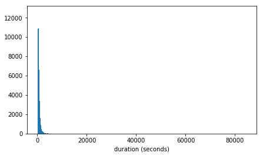

```python
# start with a standard-scaled plot

binsize = 50
bins = np.arange(0, fordbikeRiders['duration_sec'].max()+binsize, binsize)

plt.figure(figsize=[7, 4])
plt.hist(data = fordbikeRiders, x = 'duration_sec', bins = bins)
plt.xlabel('duration (seconds)')
plt.show()
```

There is a long tail in the distribution so,next we do an axis transform of the x-axis by plotting a log scale of the graph to see the actual shape of the values within the histogram specially those values that are skewered to the right

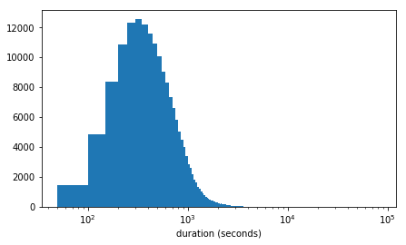

```python
bins = np.arange(0, fordbikeRiders['duration_sec'].max()+binsize, binsize)

plt.figure(figsize=[7, 4])
plt.hist(data = fordbikeRiders, x = 'duration_sec', bins = bins)
plt.xscale('log')
#plt.xticks([0,250,500, 1e3, 2e3, 5e3, 1e4, 2e4], [0,250,500, '1k', '2k', '5k', '10k','20k'])
plt.xlabel('duration (seconds)')
plt.show()
```

Duration_sec has a long-tailed distribution with some rides occuring on the higher end values od duration_sec

Next we modify the bin boundaries to make the plot more interpretable and generate more informative axis ticks,but first lets discuss the bins,by findindg the ranges and the log of those ranges

```python
np.log10(fordbikeRiders.duration_sec.describe())
```

```
count    5.242919
mean     2.847574
std      3.215427
min      1.785330
25%      2.509203
50%      2.707570
75%      2.897077
max      4.927103
Name: duration_sec, dtype: float64
```

The log ofthese values has a min of 1.7 and a max of 4.9 to base 10, so our bin edges will be 10 to the power of these values so that they are evenly spaced

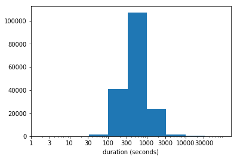

```python
bins = 10** np.arange(1.5,5+0.5,0.5)
ticks=[1,3,10,30,100,300,1000,3000,10000,30000]
labels=['{}'.format(v) for v in ticks]
#plt.figure(figsize=[7, 4])
plt.hist(data = fordbikeRiders, x = 'duration_sec', bins = bins);
plt.xscale('log');
plt.xticks(ticks,labels);
plt.xlabel('duration (seconds)')
plt.show()
```

duration in sec has a tall unimodal distribution, with most ride count occuring just alittle above 300 to 800 duration seconds values, and very few rider count in duration seconds from 3000 to 4000 seconds. When plotted on a log-scale, the duration_sec distribution shows a unimodal distribution with a clear peak between 300 and 800 in duration in secs. Interestingly, there's a steep gradual decrease in duration right after 800, rather than a smooth ramp up.

Next we look at the member_birth_year variable

### How does the member_birth_year variable perform in relation to the bike rides?

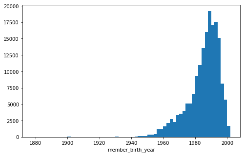

```python
# plotting member_birth_year on a standard scale
binsize = 2
bins = np.arange(1878, fordbikeRiders['member_birth_year'].max()+binsize, binsize)

plt.figure(figsize=[8, 5])
plt.hist(data = fordbikeRiders, x = 'member_birth_year', bins = bins)
#plt.xlim([0,3.5])
plt.xlabel('member_birth_year')
plt.show()
```

From the plot above we can see that the member_birth_year is skewed to the left with the peak shifting towards the right hand side of the plot,here the mode>median>mean. The plot shows a little rough bimodal distribution having two peaks between the year 1990 and 2000.This means that the most rides occurr within these member_birth_year as they seem to be the working professionals in this dataset category.The data and the plot also has some outliers in the left area, these outliers would need to be dropped from the data to give us a more meaningful and interactive plot.

# Next lets view the distributions of the left outliers as members whose birth year is 1878 would have been dead and does who are too old,with age > 93yr won't be able to ride bikes anymore

```python
fordbikeRiders[fordbikeRiders.member_birth_year < 1933].member_birth_year.value_counts()
```

```
1931    89
1900    53
1902    11
1901     6
1920     3
1930     1
1928     1
1927     1
1910     1
1878     1
Name: member_birth_year, dtype: int64
```

Next we do a distribution of these norminal categories:day of week, hour of day, start_station_id, end_station_id,user_type member_gender,and bike_share_for_all_trip to see how the distrubition of these variables perform

```python
fordbikeRiders.head(2)
```

|  | duration_sec | start_time | end_time | start_station_id | start_station_name | end_station_id | end_station_name | bike_id | user_type | member_birth_year | member_gender | bike_share_for_all_trip | start_day | start_hour | end_day | end_hour |
| --- | --- | --- | --- | --- | --- | --- | --- | --- | --- | --- | --- | --- | --- | --- | --- | --- |
| 0 | 52185 | 2019-02-28 17:32:10.145 | 2019-03-01 08:01:55.975 | 21 | Montgomery St BART Station (Market St at 2nd St) | 13 | Commercial St at Montgomery St | 4902 | Customer | 1984 | Male | No | Thu | 17 | Fri | 8 |
| 2 | 61854 | 2019-02-28 12:13:13.218 | 2019-03-01 05:24:08.146 | 86 | Market St at Dolores St | 3 | Powell St BART Station (Market St at 4th St) | 5905 | Customer | 1972 | Male | No | Thu | 12 | Fri | 5 |

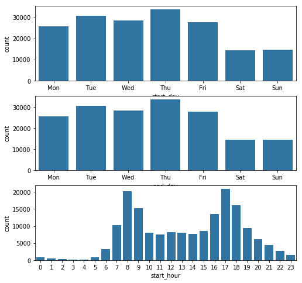

```python
# let's plot all three together to get an idea of each ordinal variable's distribution.
fig, ax = plt.subplots(nrows=3, figsize = [8,8])

default_color = sb.color_palette()[0]

sb.countplot(data = fordbikeRiders, x = 'start_day', color = default_color, ax = ax[0])
#plt.xlabel('start_day')

sb.countplot(data = fordbikeRiders, x = 'end_day', color = default_color, ax = ax[1])
#plt.xlabel('end_day')

sb.countplot(data = fordbikeRiders, x = 'start_hour', color = default_color, ax = ax[2])
#plt.xlabel('start_hour')
```

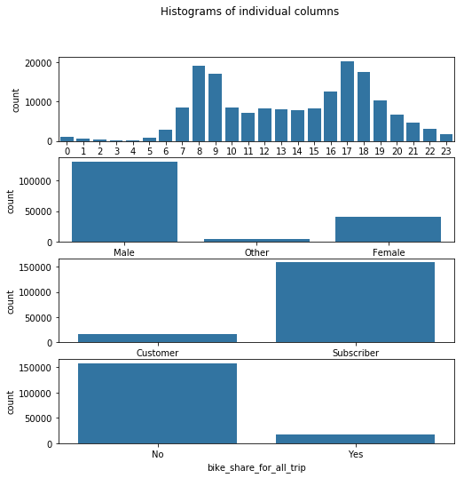

```python
# let's plot all three together to get an idea of each ordinal variable's distribution.
fig, ax = plt.subplots(nrows=4, figsize = [8,8])

default_color = sb.color_palette()[0]
sb.countplot(data = fordbikeRiders, x = 'end_hour', color = default_color, ax = ax[0])
#plt.xlabel('end_hour')

sb.countplot(data = fordbikeRiders, x = 'member_gender', color = default_color, ax = ax[1])

sb.countplot(data = fordbikeRiders, x = 'user_type', color = default_color, ax = ax[2])
sb.countplot(data = fordbikeRiders, x = 'bike_share_for_all_trip', color = default_color, ax = ax[3])
plt.suptitle("Histograms of individual columns")
#plt.xlabel('end_hour')
#plt.xlabel('start_hour')
plt.show()
```

Plotting these variables above,again with better visualization of their axis shown below

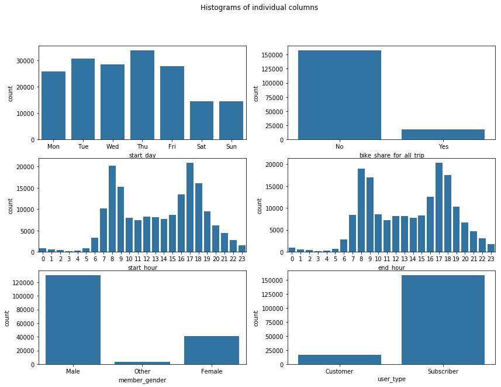

```python
# let's plot all three together to get an idea of each ordinal variable's distribution.
fig, ax = plt.subplots(nrows=3, ncols = 2, figsize = [14,10])

default_color = sb.color_palette()[0]
sb.countplot(data = fordbikeRiders, x = 'start_day', color = default_color, ax = ax[0, 0])
sb.countplot(data = fordbikeRiders, x = 'bike_share_for_all_trip', color = default_color, ax = ax[0, 1])


sb.countplot(data = fordbikeRiders, x = 'start_hour', color = default_color, ax = ax[1, 0])
sb.countplot(data = fordbikeRiders, x = 'end_hour', color = default_color, ax = ax[1, 1])



sb.countplot(data = fordbikeRiders, x = 'member_gender', color = default_color, ax = ax[2, 0])
sb.countplot(data = fordbikeRiders, x = 'user_type', color = default_color, ax = ax[2, 1])

#sb.countplot(data = fordbikeRiders, x = 'bike_share_for_all_trip', color = default_color, ax = ax[3, 0])

plt.suptitle("Histograms of individual columns")

plt.show()
```

The bike ride activity of the fordbikeRiders dataset is generally quite good, with the highest rides occurring on thursday with the highest count of more than 30,000 rides for both the start_day and end_day variables.What this means is that most professionals and working class members use the rides more for their daily activities on thursdays,even though the count on monday which is presumably the first working day of the week is 25,000 which is not up to thursdays count, I would assume some professionals work from home on this day,however the ride counts for saturday and sunday is the lowest with less than 15,000 rides happening meaning that an average bike rider would probably not ride a bike during the weekends unless it ia absolutely neccessary and ofcourse most of them do not work during the weekends.

The start_hour and end_hour plots are both with the highest count for start_hour at 8 and 17hours respectively.This means that riders resume their duty post for the days job at 8am and close from work at 17hour for each ride day.

The user_type variable has the highest count of above 150,000 rides being from subscribers whereas only about 20,000 count of those rides where made by Customers, meaning most bike hires rides where made my mostly male subscribers.

The bike share for all trip plot shows a high bar count of 150,000 riders not sharing their bikes during each trip,while about 20,000 riders shared their bikes during the course of their rides.

### Next lets remove outliers from the duration_sec variable to remove all inconsistent data

```python
#remove the outliers
fordbikeRiders = fordbikeRiders[fordbikeRiders.duration_sec < 1000]
```

I'll now look at the other features in the data to see if any of them hold interesting properties.

### What end_day of the week has the most bike usage?

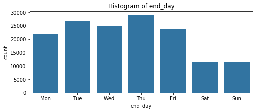

```python
fig, ax = plt.subplots(nrows=1, figsize = [8,3])

default_color = sb.color_palette()[0]

sb.countplot(data = fordbikeRiders, x = 'end_day', color = default_color, ax = ax)
plt.title("Histogram of end_day");
```

```python
fordbikeRiders.head(3)
```

|  | duration_sec | start_time | end_time | start_station_id | start_station_name | end_station_id | end_station_name | bike_id | user_type | member_birth_year | member_gender | bike_share_for_all_trip | start_day | start_hour | end_day | end_hour |
| --- | --- | --- | --- | --- | --- | --- | --- | --- | --- | --- | --- | --- | --- | --- | --- | --- |
| 10 | 458 | 2019-02-28 23:57:57.211 | 2019-03-01 00:05:35.435 | 370 | Jones St at Post St | 43 | San Francisco Public Library (Grove St at Hyde... | 5318 | Subscriber | 1996 | Female | Yes | Thu | 23 | Fri | 0 |
| 11 | 506 | 2019-02-28 23:56:55.540 | 2019-03-01 00:05:21.733 | 44 | Civic Center/UN Plaza BART Station (Market St ... | 343 | Bryant St at 2nd St | 5848 | Subscriber | 1993 | Male | No | Thu | 23 | Fri | 0 |
| 14 | 395 | 2019-02-28 23:56:26.848 | 2019-03-01 00:03:01.947 | 243 | Bancroft Way at College Ave | 252 | Channing Way at Shattuck Ave | 4786 | Subscriber | 1988 | Male | No | Thu | 23 | Fri | 0 |

### What start_station_id was the most frequently and the least frequently used?

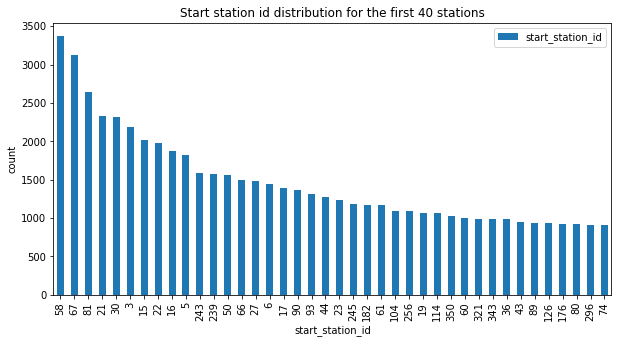

```python
#plot histogram ofthe 40 start stations with most activity

default_color = sb.color_palette()[0]

fordbikeRiders.start_station_id.value_counts().reset_index().iloc[:40].plot(kind="bar", x="index",color=default_color,figsize = [10,5])
plt.title("Start station id distribution for the first 40 stations");
plt.xlabel("start_station_id")
plt.ylabel('count');
```

### What end_station_id was the most frequently used?

[figure not shown]

```python
#plot histogram of the 40 end stations with most activity

default_color = sb.color_palette()[0]

fordbikeRiders.start_station_id.value_counts().reset_index().iloc[:40].plot(kind="bar", x="index",color=default_color,figsize = [10,5])
plt.title("End station id distribution for the first 40 stations");
plt.xlabel("end_station_id")
plt.ylabel('count');
```

### What bike_id had the highest usage in the forebikeshare dataset?

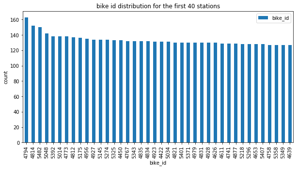

```python
#plot histogram of the 40 bike id with most activity

default_color = sb.color_palette()[0]

fordbikeRiders.bike_id.value_counts().reset_index().iloc[:40].plot(kind="bar", x="index",color=default_color,figsize = [10,5])
plt.title("bike id distribution for the first 40 stations");
plt.xlabel("bike_id")
plt.ylabel('count');
```

### Doing a log transformation of our duration_sec column

```python
fordbikeRiders["duration_log"] = np.log10(fordbikeRiders["duration_sec"])
```

> **Rubric Tip**: Visualizations should depict the data appropriately so that the plots are easily interpretable. You should choose an appropriate plot type, data encodings, and formatting as needed. The formatting may include setting/adding the title, labels, legend, and comments. Also, do not overplot or incorrectly plot ordinal data.

### Discuss the distribution(s) of your variable(s) of interest. Were there any unusual points? Did you need to perform any transformations?

The distributions of my variable of interest which are duration_sec,start_time,end_time and member_birth_year. The duration_sec plot had unusual unimodal distribution that was skewed to the right with a long tail, so I had to do a log transformation, Under the transformation, the data looked unimodal, with the peak between 300𝑎𝑛𝑑 800 duration_seconds.

## Bivariate Exploration

To start off with, I want to look at the pairwise correlations present between features in the data.

```python
fordbikeRiders.head(5)
```

|  | duration_sec | start_time | end_time | start_station_id | start_station_name | end_station_id | end_station_name | bike_id | user_type | member_birth_year | member_gender | bike_share_for_all_trip | start_day | start_hour | end_day | end_hour | duration_log |
| --- | --- | --- | --- | --- | --- | --- | --- | --- | --- | --- | --- | --- | --- | --- | --- | --- | --- |
| 10 | 458 | 2019-02-28 23:57:57.211 | 2019-03-01 00:05:35.435 | 370 | Jones St at Post St | 43 | San Francisco Public Library (Grove St at Hyde... | 5318 | Subscriber | 1996 | Female | Yes | Thu | 23 | Fri | 0 | 2.660865 |
| 11 | 506 | 2019-02-28 23:56:55.540 | 2019-03-01 00:05:21.733 | 44 | Civic Center/UN Plaza BART Station (Market St ... | 343 | Bryant St at 2nd St | 5848 | Subscriber | 1993 | Male | No | Thu | 23 | Fri | 0 | 2.704151 |
| 14 | 395 | 2019-02-28 23:56:26.848 | 2019-03-01 00:03:01.947 | 243 | Bancroft Way at College Ave | 252 | Channing Way at Shattuck Ave | 4786 | Subscriber | 1988 | Male | No | Thu | 23 | Fri | 0 | 2.596597 |
| 15 | 208 | 2019-02-28 23:59:18.548 | 2019-03-01 00:02:47.228 | 349 | Howard St at Mary St | 60 | 8th St at Ringold St | 6361 | Subscriber | 1993 | Male | Yes | Thu | 23 | Fri | 0 | 2.318063 |
| 16 | 548 | 2019-02-28 23:50:41.607 | 2019-02-28 23:59:49.953 | 131 | 22nd St at Dolores St | 71 | Broderick St at Oak St | 6572 | Subscriber | 1981 | Male | No | Thu | 23 | Thu | 23 | 2.738781 |

```python
numeric_vars = ['member_birth_year', 'start_hour', 'end_hour','duration_sec','end_station_id','start_station_id']
categoric_vars = ['member_gender', 'start_day','bike_share_for_all_trip','user_type',]#'end_day'
```

Next we plot a correlation plot

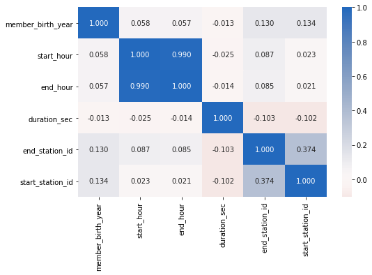

```python
# correlation plot
plt.figure(figsize = [8, 5])
sb.heatmap(fordbikeRiders[numeric_vars].corr(), annot = True, fmt = '.3f',
           cmap = 'vlag_r', center = 0)
plt.show()
```

```
fordbikeRiders.shape= (149342, 17)
fordbikeRiders_samp.shape= (500, 17)
```

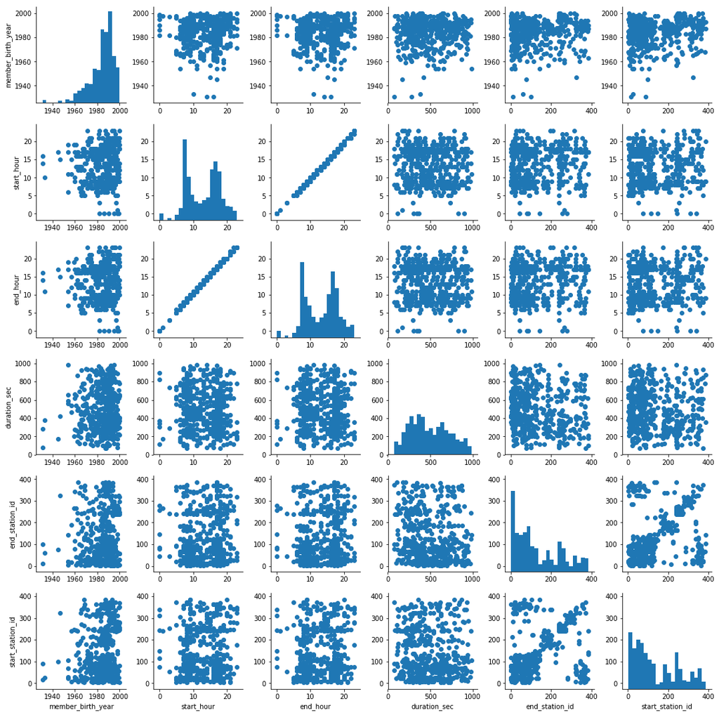

```python
# plot matrix: sample 500 fordbikeRiders so that plots are clearer and they render faster
print("fordbikeRiders.shape=",fordbikeRiders.shape)
fordbikeRiders_samp = fordbikeRiders.sample(n=500, replace = False)
print("fordbikeRiders_samp.shape=",fordbikeRiders_samp.shape)

g = sb.PairGrid(data = fordbikeRiders_samp, vars = numeric_vars)
g = g.map_diag(plt.hist, bins = 20);
g.map_offdiag(plt.scatter);
```

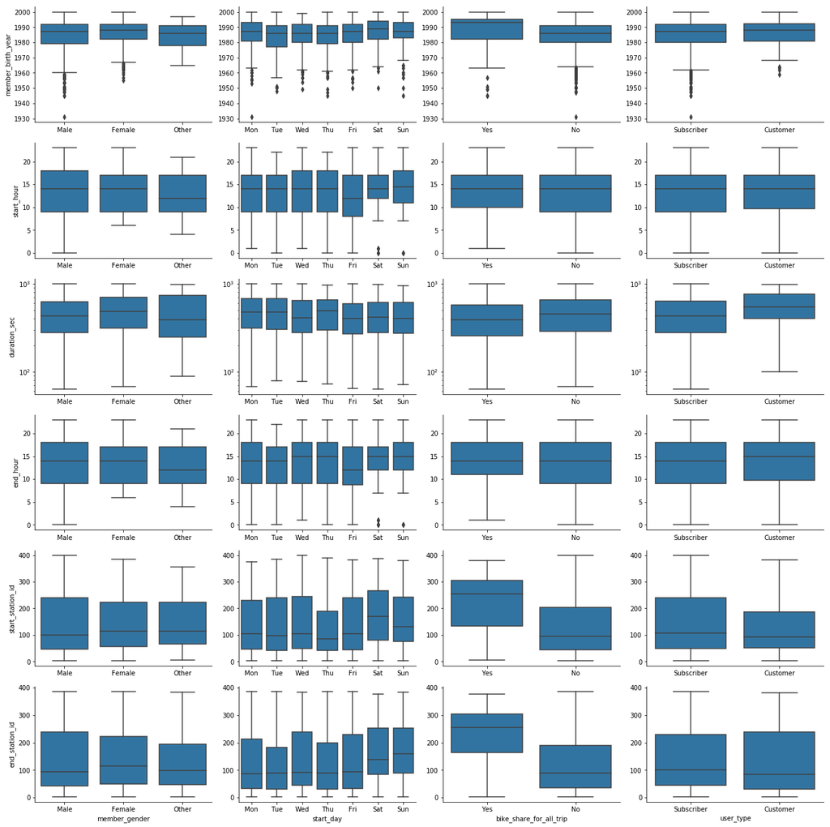

```python
# plot matrix of numeric features against categorical features.
# can use a larger sample since there are fewer plots and they're simpler in nature.

# Deprecated
# samples = np.random.choice(fordbikeRiders.shape[0], 2000, replace = False)
# fordbikeRiders_samp = fordbikeRiders.loc[samples,:]

fordbikeRiders_samp = fordbikeRiders.sample(n=2000, replace = False)


def boxgrid(x, y, **kwargs):
    """ Quick hack for creating box plots with seaborn's PairGrid. """
    default_color = sb.color_palette()[0]
    sb.boxplot(x=x, y=y, color=default_color)
    if y.name == "duration_sec":
        plt.yscale('log');

plt.figure(figsize = [13, 13])
g = sb.PairGrid(data = fordbikeRiders_samp, y_vars = ['member_birth_year', 'start_hour','duration_sec','end_hour','start_station_id','end_station_id'], x_vars = categoric_vars,
                size = 3, aspect = 1.5);
g.map(boxgrid);
plt.show();
```

One thing I can note from this is that the customer's mean duration sec is higher than the subscriber's. This is a little intriguing.

Those who use bikes for all professional purposes tend to be younger, start their trips later, and have shorter average trips than those who don't.

I should note that because the data is sampled, each time it is run, the visualisations will be slightly different.

The start_day's plots don't say much.

The variables user_type, start_day, member_gender,and bike share for all trip.Next I will check the relationshipss between the categorical variables.

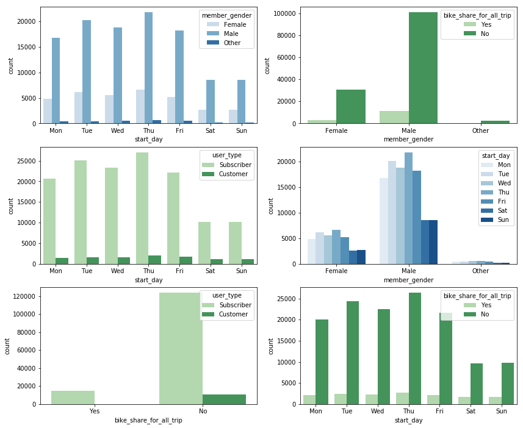

```python
# since there's only three subplots to create, using the full data should be fine.
plt.figure(figsize = [14, 12])

# subplot 1: member_gender vs user_type
plt.subplot(3, 2, 1)
sb.countplot(data = fordbikeRiders, x = 'start_day', hue = 'member_gender', palette = 'Blues')

# subplot 2: 'member_gender' vs'bike_share_for_all_trip'
ax = plt.subplot(3, 2, 2)
sb.countplot(data = fordbikeRiders, x = 'member_gender', hue = 'bike_share_for_all_trip', palette = 'Greens')
#ax.legend(loc = 1, ncol = 2) # re-arrange legend to remove overlapping

# subplot 3: 'bike_share_for_all_trip' vs'user_type'
ax = plt.subplot(3, 2, 5)
sb.countplot(data = fordbikeRiders, x = 'bike_share_for_all_trip', hue = 'user_type', palette = 'Greens')
#ax.legend(loc = 1, ncol = 2)

# subplot 4:  'member_gender' vs'start_day'
ax = plt.subplot(3, 2, 4)
sb.countplot(data = fordbikeRiders, x = 'member_gender', hue = 'start_day', palette = 'Blues')
#ax.legend(loc=1,ncol = 2)

# subplot 5: 'start_day' vs'user_type'
ax = plt.subplot(3, 2, 3)
sb.countplot(data = fordbikeRiders, x = 'start_day', hue = 'user_type', palette = 'Greens')
#ax.legend(loc = 1, ncol = 2) # re-arrange legend to remove overlapping

# subplot 6: 'start_day' vs'bike_share_for_all_trip'
ax = plt.subplot(3, 2, 6)
sb.countplot(data = fordbikeRiders, x = 'start_day', hue = 'bike_share_for_all_trip', palette = 'Greens')
#ax.legend(loc = 1, ncol = 2)

plt.show()
```

This again supports every previous analysis. Male members are higher than female members, Thursdays are the busiest, while Saturdays and Sundays are the same.

It's interesting to note that no users of the bike share programme are present for all rides. Subscribers are those who utilise the bike share on all of their journeys. Last but not least, whether a member uses the bike share on every journey is unrelated to their gender.

### What start_hour is the busiest for the member_birth_year variable ?

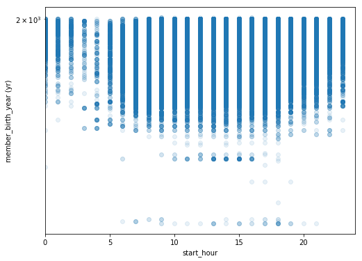

```python
# scatter plot of member_birth_year,vs. start_hour  with log transform on member_birth_year axis

plt.figure(figsize = [8, 6])
plt.scatter(data = fordbikeRiders, x = 'start_hour', y = 'member_birth_year', alpha = 1/10)
plt.xlim([0,24])
plt.xlabel('start_hour')
plt.yscale('log')
#plt.yticks([500, 1e3, 2e3, 5e3, 1e4, 2e4], [500, '1k', '2k', '5k', '10k', '20k'])
plt.ylabel('member_birth_year (yr)')
plt.show()
```

The categorical variables, start day, member gender, bike share for all trip, and "user type" have distributions for duration sec, start hour, and member birth year. Let's look at these distributions again with their log transformation.

### What member_birth_year category has the longest duration_sec?

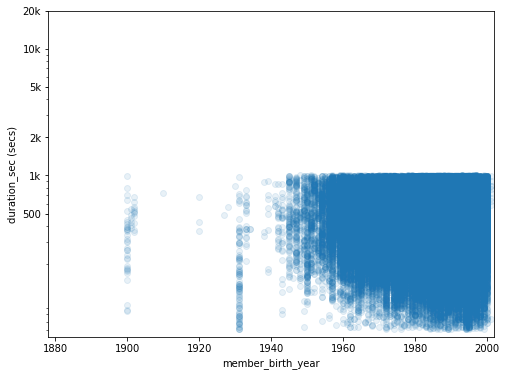

```python
# scatter plot of duration_sec vs. member_birth_year, with log transform on duration_sec axis

plt.figure(figsize = [8, 6])
plt.scatter(data = fordbikeRiders, x = 'member_birth_year', y = 'duration_sec', alpha = 1/10)
plt.xlim([1878,2002])
plt.xlabel('member_birth_year')
plt.yscale('log')
plt.yticks([500, 1e3, 2e3, 5e3, 1e4, 2e4], [500, '1k', '2k', '5k', '10k', '20k'])
plt.ylabel('duration_sec (secs)')
plt.show()
```

### What start_hours gives longer durations?

Next I will see how the duration vary with the start hour. Are some hours known for longer duration?

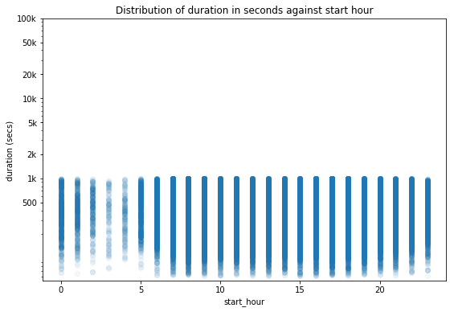

```python
# scatter plot of duration vs. start_hour, with log transform on duration axis
plt.figure(figsize = [9, 6])
plt.scatter(data = fordbikeRiders, x = 'start_hour', y = 'duration_sec', alpha = 1/20)
plt.xlabel('start_hour')
plt.title("Distribution of duration in seconds against start hour")
plt.yscale('log')
plt.yticks([500, 1e3, 2e3, 5e3, 10e3, 20e3, 5e4, 10e4], [500, '1k', '2k', '5k', '10k', '20k', '50k', '100k'])
plt.ylabel('duration (secs) ')
plt.show()
```

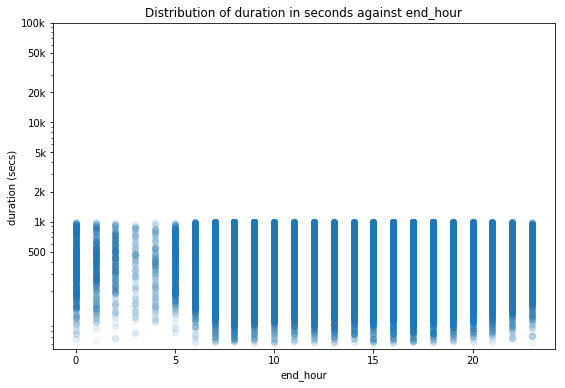

```python
# scatter plot of duration vs. end_hour, with log transform on duration axis
plt.figure(figsize = [9, 6])
plt.scatter(data = fordbikeRiders, x = 'end_hour', y = 'duration_sec', alpha = 1/20)
plt.xlabel('end_hour')
plt.title("Distribution of duration in seconds against end_hour")
plt.yscale('log')
plt.yticks([500, 1e3, 2e3, 5e3, 10e3, 20e3, 5e4, 10e4], [500, '1k', '2k', '5k', '10k', '20k', '50k', '100k'])
plt.ylabel('duration (secs) ')
plt.show()
```

Now, let's take a second look at the duration_sec and start_hour, and member birth_year distributions on the three categorical variables: 'start_day', 'member_gender', 'bike_share_for_all_trip', "user_type". Befort that we can define a function that will help us withthe log transforms

```python
# compute the logarithm of duration to make multivariate plotting easier
def logrithmicTrnsfm(x, inverse = False):
    """ quick function for computing log and power operations """
    if not inverse:
        return np.log10(x)
    else:
        return np.power(10, x)
#diamonds['log_price'] = diamonds['price'].apply(log_trans)
```

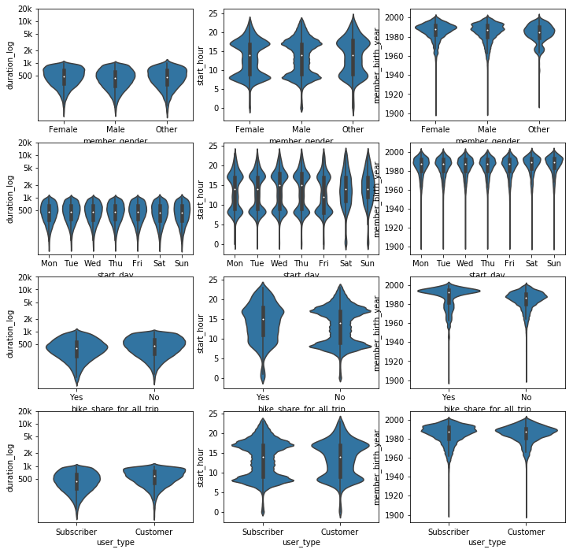

```python
# plot the categorical variables against duration_sec and start_hour and member_birth_year again, this time
# with full data and variable transforms
fig, ax = plt.subplots(ncols = 3, nrows = 4 , figsize = [12,12])

for i in range(len(categoric_vars)):
    var = categoric_vars[i]
    sb.violinplot(data = fordbikeRiders, x = var, y = 'duration_log', ax = ax[i,0],
               color = default_color)
    ax[i,0].set_yticks(logrithmicTrnsfm(np.array([500, 1e3, 2e3, 5e3, 1e4, 2e4])))
    ax[i,0].set_yticklabels([500, '1k', '2k', '5k', '10k', '20k'])
    sb.violinplot(data = fordbikeRiders, x = var, y = 'start_hour', ax = ax[i,1],
               color = default_color)

    sb.violinplot(data = fordbikeRiders, x = var, y = 'member_birth_year', ax = ax[i,2],
               color = default_color)
    #ax[i,1].set_yticks(cuberoot_trans(np.array(carat_ticks)))
    #ax[i,1].set_yticklabels(carat_ticks)
    #ax[i,1].set_ylim(cuberoot_trans(np.array([0.1, 3.5])))

plt.show()
```

I believe that women tend to bike for longer periods of time than males do on average when I take into account the box plot and the violin plot. I notice that the violin plot for female members appears to be considerably raised when comparing member gender against duration sec. Men use the shorter duration more often.

I also observed that Saturday and Sunday have a somewhat different violin shape than the other days of the week on the plot of start hour against start day. This indicates that, in contrast to weekdays, when people use the bike sharing system in the morning and after work in the evenings, people utilise it mostly in the afternoons on weekends. Namely, 9am to 9pm.

While not immediately apparent, the first graphic demonstrates that Saturday and Sunday have points in the outlier zone. The top of the violin tapers more.

I can identify that persons who use the bike share for all trips are often younger than those who don't by comparing the bike share for all trips against age.

## Multivariate Exploration

I started by defining a function first, I used this as a quick hack for creating heat maps with seaborn's pairgrid

```python
def hist2dgrid(x, y, **kwargs):
    """ Quick hack for creating heat maps with seaborn's PairGrid. """
    palette = kwargs.pop('color')
    the_yr = kwargs.pop('the_yr')
    the_durtion = kwargs.pop('the_durtion')
    if the_yr:
        bins_x = np.arange(1970, 2002+2, 2)
    else:
        bins_x = np.arange(0, 24)
    if the_durtion:
        bins_y = np.arange(1.5, 3.7+0.2, 0.2)
        plt.yticks(logrithmicTrnsfm(np.array([500, 1e3, 2e3, 5e3, 10e3])), [500, '1k', '2k', '5k', "10k"])
        plt.hist2d(x, np.log10(y), bins = [bins_x, bins_y], cmap = palette, cmin = 5)
    else:
        bins_y = np.arange(1970, 2002+2, 2)
        plt.hist2d(x, y, bins = [bins_x, bins_y], cmap = palette, cmin = 5)
```

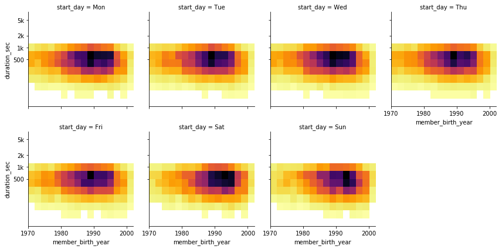

```python
# create faceted heat maps on levels of the day variable
g = sb.FacetGrid(data = fordbikeRiders, col = 'start_day', col_wrap = 4, size = 3  )
g.map(hist2dgrid, 'member_birth_year', 'duration_sec',  color = 'inferno_r', the_yr=True, the_durtion=True)
g.set_xlabels('member_birth_year')
g.set_ylabels('duration_sec')
# plt.figure(figsize = [9, 12])
# plt.suptitle("Heat maps of duration across start day and member birth year(age)")
plt.show()
```

From the distributions above I noticed that the likelihood that people will use their bikes for extended periods of time is mostly independent of the time of day. This plot also shows that younger users are more active on the system, and the histogram and scatterplot of member_birth_year vs. duration show that this is also accurate. This fits with the violin plot from the previous section.

### How does duration_sec, affect member_gender and start_hour?

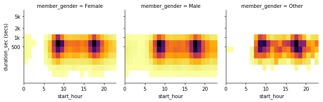

```python
# create faceted heat maps on member gender variable
g = sb.FacetGrid(data = fordbikeRiders, col = 'member_gender', col_wrap = 4, size= 3)
g.map(hist2dgrid, 'start_hour', 'duration_sec',  color = 'inferno_r', the_yr = False,   the_durtion=True)
g.set_xlabels('start_hour')
g.set_ylabels('duration_sec (secs)')

plt.show()
```

Male and female exhibit the same traits during the course of the day, once more. So it's fair to say that women are less likely to utilise bicycles at night based on the empty gaps on the female map on the left than men.

### How does duration_sec fair generally in respect to start_hour and user_type?

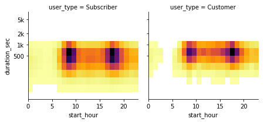

```python
# create faceted heat maps on user type variable
g = sb.FacetGrid(data = fordbikeRiders, col = 'user_type', col_wrap = 4, size = 3 )
g.map(hist2dgrid, 'start_hour', 'duration_sec',  color = 'inferno_r', the_yr = False,  the_durtion=True)
g.set_xlabels('start_hour')
g.set_ylabels('duration_sec')

plt.show()
```

### How does bike_share_for_all_trip perform in respect to duration_sec and start_hour?

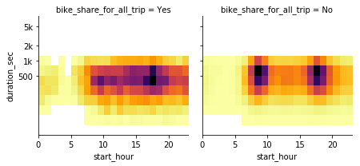

```python
# create faceted heat maps on bike_share_for_all_trip variable
g = sb.FacetGrid(data = fordbikeRiders, col = 'bike_share_for_all_trip', col_wrap = 4, size = 3)
g.map(hist2dgrid, 'start_hour', 'duration_sec',  color = 'inferno_r', the_yr = False, the_durtion=True)
g.set_xlabels('start_hour')
g.set_ylabels('duration_sec')

plt.show()
```

### How does the start_day variable relate with start_hour and member_birth_year?

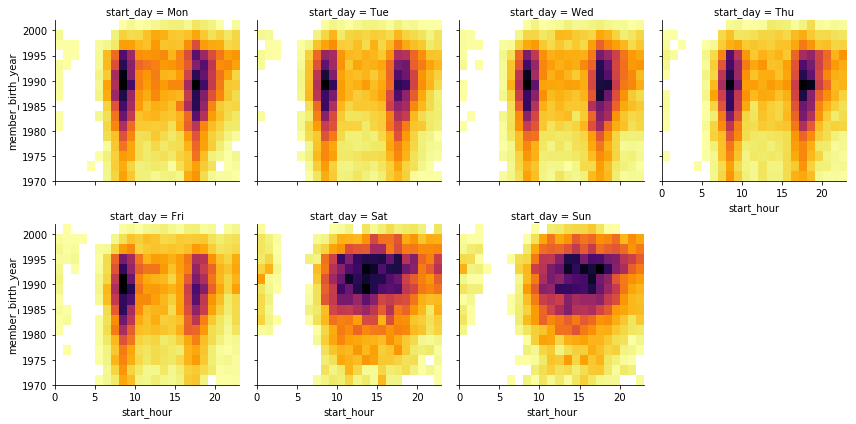

```python
# create faceted heat maps on start_day variable
g = sb.FacetGrid(data =fordbikeRiders, col = 'start_day', col_wrap = 4, size= 3   )
g.map(hist2dgrid, 'start_hour', 'member_birth_year',  color = 'inferno_r', the_yr = False, the_durtion=False)
g.set_xlabels('start_hour')
g.set_ylabels('member_birth_year')

plt.show()
```

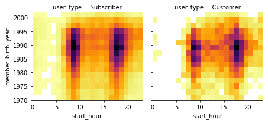

```python
# create faceted heat maps on levels of the user_type variable
g = sb.FacetGrid(data = fordbikeRiders, col = 'user_type', col_wrap = 4, size = 3   )
g.map(hist2dgrid, 'start_hour', 'member_birth_year',  color = 'inferno_r', the_yr = False, the_durtion=False)
g.set_xlabels('start_hour')
g.set_ylabels('member_birth_year')

plt.show()
```

In the following figures below, we would use a point plot to analyse and visualize the variables relationships

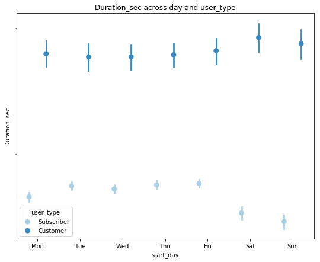

```python
fig = plt.figure(figsize = [9,7])
ax = sb.pointplot(data = fordbikeRiders, x = 'start_day', y = 'duration_sec', hue = 'user_type',
           palette = 'Blues', linestyles = '', dodge = 0.4)
plt.title('Duration_sec across day and user_type')
plt.ylabel('Duration_sec')
plt.yscale('log')
# plt.yticks([2e3, 4e3, 6e3, 1e4], ['2k', '4k', '6k', '10k'])
ax.set_yticklabels([],minor = True)
plt.show();
```

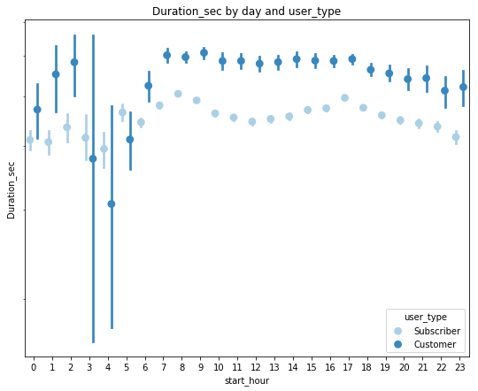

```python
fig = plt.figure(figsize = [9,7])
ax = sb.pointplot(data = fordbikeRiders, x = 'start_hour', y = 'duration_sec', hue = 'user_type',
           palette = 'Blues', linestyles = '', dodge = 0.4)
plt.title('Duration_sec by day and user_type')
plt.ylabel('Duration_sec')
plt.yscale('log')
ax.set_yticklabels([],minor = True)
plt.show();
```

Same conclusion with the previous graph

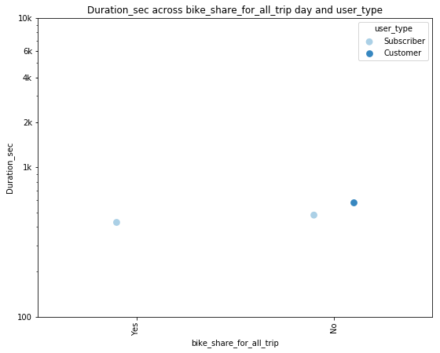

```python
fig = plt.figure(figsize = [9,7])
ax = sb.pointplot(data = fordbikeRiders, x = 'bike_share_for_all_trip', y = 'duration_sec', hue = 'user_type',
           palette = 'Blues', linestyles = '', dodge = 0.2)
plt.title('Duration_sec across bike_share_for_all_trip day and user_type')
plt.ylabel('Duration_sec')
plt.yscale('log')
plt.xticks(rotation=90)
plt.yticks([100, 1000, 2e3, 4e3, 6e3, 1e4], ["100","1k", '2k', '4k', '6k', '10k'])
ax.set_yticklabels([],minor = True)
# ax.legend(loc = 1, ncol = 2)
plt.show();
```

Again, there are no user_type customers with bike share for all journeys. Subscribers are those who utilise the bike share on all of their journeys as customers typically stay for longer.

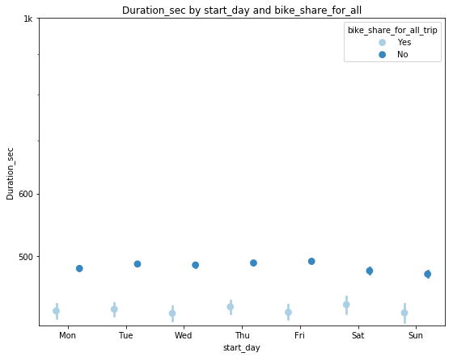

```python
fig = plt.figure(figsize = [9,7])
ax = sb.pointplot(data = fordbikeRiders, x = 'start_day', y = 'duration_sec', hue = 'bike_share_for_all_trip',
           palette = 'Blues', linestyles = '', dodge = 0.4)
plt.title('Duration_sec by start_day and bike_share_for_all')
plt.ylabel('Duration_sec')
plt.yscale('log')
plt.yticks([500, 600, 1e3], [ "500", "600", '1k'])
ax.set_yticklabels([],minor = True)
plt.show();
```

[figure not shown]

```python
fig = plt.figure(figsize = [11,7])
ax = sb.pointplot(data = fordbikeRiders, x = 'member_birth_year', y = 'duration_sec', hue = 'user_type',
           palette = 'Blues', linestyles = '', dodge = 0.4)
plt.title('Duration_sec by member_birtth_year and user_type')
plt.ylabel('Duration_sec')
plt.yscale('log')
plt.xticks(rotation=90)
plt.yticks([100, 1000, 2e3, 4e3, 6e3, 1e4], ["100","1k", '2k', '4k', '6k', '10k'])
ax.set_yticklabels([],minor = True)
plt.show();
```

The distribution plot above does not have much elderly customers. That could explain why younger folks make up a larger portion of the outliers. Since we've already demonstrated that customers are primarily to blame for the dataset's increased duration

### Were there any interesting or surprising interactions between features?

It was intriguing to note that customers, especially females often had greater duration hours than males. Also, I noticed that all plots had more variance for the customers than for the variables that contributed less to the duration sec increase.

## Conclusions

During the data exploration,I cleaned the data, splitted the days and hours from the datetime, changed some columns' data types, and removed unneccessary columns from the dataset in order to get the aforementioned conclusions. I then carried out monovariate exploration and visualization, followed by bivariate andlastly multivariate exploration and visualization of the dataset.